# Project 2

K. Huisamen

29 April 2016

# Plots

## Plot1

Have total emissions from PM2.5 decreased in the United States from 1999 to 2008? Using the base plotting system, make a plot showing the total PM2.5 emission from all sources for each of the years 1999, 2002, 2005, and 2008.

```
##
## > setwd("~/40 L&G/Coursera/ExDataAnalysis/Project2")
##
## > if (!exists("NEI")) {
## +     NEI <- readRDS(paste0(getwd(), "/Data/summarySCC_PM25.rds"))
## + }
##
## > png(filename = paste0("plot1.png"), height = 295,
## +     width = 600, bg = "white")
##
## > library(dplyr)
```

```
##
## > df <- NEI %>% select(Emissions, year) %>% group_by(year) %>%
## +     summarise(Total = sum(Emissions))
##
## > with(df, plot.default(x = year, y = Total, type = "b",
## +     xlab = "Year", ylab = "Tons of PM2.5", main = "Total Annual Emissions"))
```

```
##
## > dev.off()
## png
##   2
```

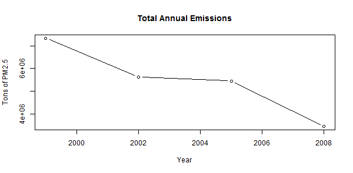

```r
source("plot1.R", echo = TRUE)
```

## Plot 2

Have total emissions from PM2.5 decreased in the Baltimore City, Maryland (fips == “24510”) from 1999 to 2008? Use the base plotting system to make a plot answering this question.

```
##
## > setwd("~/40 L&G/Coursera/ExDataAnalysis/Project2")
##
## > if (!exists("NEI")) {
## +     NEI <- readRDS(paste0(getwd(), "/Data/summarySCC_PM25.rds"))
## + }
##
## > png(filename = paste0("plot2.png"), height = 295,
## +     width = 600, bg = "white")
##
## > library(dplyr)
##
## > df <- NEI %>% select(Emissions, year, fips) %>% filter(fips ==
## +     "24510") %>% group_by(year) %>% summarise(Total = sum(Emissions))
##
## > with(df, plot.default(x = year, y = Total, type = "b",
## +     xlab = "Year", ylab = "Tons of PM2.5", main = "Total Annual Emissions",
## +     sub = " ..." ... [TRUNCATED]
```

```
##
## > dev.off()
## png
##   2
```

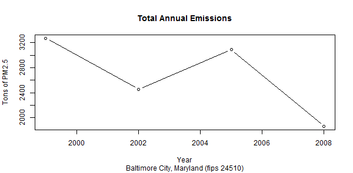

```r
source("plot2.R", echo = TRUE)
```

## Plot3

Of the four types of sources indicated by the type (point, nonpoint, onroad, nonroad) variable, which of these four sources have seen decreases in emissions from 1999–2008 for Baltimore City?

```
##
## > setwd("~/40 L&G/Coursera/ExDataAnalysis/Project2")
##
## > if (!exists("NEI")) {
## +     NEI <- readRDS(paste0(getwd(), "/Data/summarySCC_PM25.rds"))
## + }
##
## > png(filename = paste0("plot3.png"), height = 295,
## +     width = 600, bg = "white")
##
## > library(dplyr)
##
## > df <- NEI %>% select(Emissions, year, Source = type,
## +     fips) %>% filter(fips == "24510", year %in% c(1999, 2008),
## +     !Source == "POINT") %> .... [TRUNCATED]
##
## > library(ggplot2)
```

```
##
## > qplot(x = year, y = Total, data = df, geom = c("point",
## +     "line"), group = Source, col = Source, xlab = "Year", ylab = "Tons of PM2.5",
## +      .... [TRUNCATED]
```

```
##
## > dev.off()
## png
##   2
```

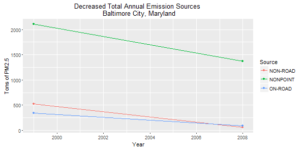

```r
source("plot3.R", echo = TRUE)
```

## Plot4

Which have seen increases in emissions from 1999–2008? Use the *ggplot2* plotting system to make a plot answer this question.

```
##
## > setwd("~/40 L&G/Coursera/ExDataAnalysis/Project2")
##
## > if (!exists("NEI")) {
## +     NEI <- readRDS(paste0(getwd(), "/Data/summarySCC_PM25.rds"))
## + }
##
## > png(filename = paste0("plot4.png"), height = 295,
## +     width = 600, bg = "white")
##
## > library(dplyr)
##
## > df <- NEI %>% select(Emissions, year, Source = type,
## +     fips) %>% filter(fips == "24510", year %in% c(1999, 2008),
## +     Source == "POINT") %>% .... [TRUNCATED]
##
## > library(ggplot2)
##
## > qplot(x = year, y = Total, data = df, geom = c("point",
## +     "line"), group = Source, col = Source, xlab = "Year", ylab = "Tons of PM2.5",
## +      .... [TRUNCATED]
```

```
##
## > dev.off()
## png
##   2
```

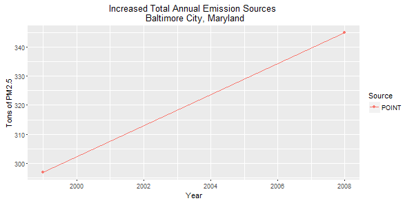

```r
source("plot4.R", echo = TRUE)
```

## Plot5

Across the United States, how have emissions from coal combustion-related sources changed from 1999–2008?

```
##
## > setwd("~/40 L&G/Coursera/ExDataAnalysis/Project2")
##
## > if (!exists("NEI")) {
## +     NEI <- readRDS(paste0(getwd(), "/Data/summarySCC_PM25.rds"))
## + }
##
## > if (!exists("SCC")) {
## +     SCC <- readRDS(paste0(getwd(), "/Data/Source_Classification_Code.rds"))
## + }
##
## > library(dplyr)
##
## > coalcomb <- SCC %>% filter(grepl("comb", x = Short.Name,
## +     ignore.case = TRUE)) %>% filter(grepl("coal", x = Short.Name,
## +     ignore.case = T .... [TRUNCATED]
##
## > coalcomb <- coalcomb %>% .$SCC
##
## > png(filename = paste0("plot5.png"), height = 295,
## +     width = 600, bg = "white")
##
## > df <- NEI %>% select(Emissions, year, Source = type,
## +     SCC) %>% filter(SCC %in% coalcomb) %>% group_by(year) %>%
## +     summarise(Total = sum(E .... [TRUNCATED]
##
## > library(ggplot2)
##
## > qplot(x = year, y = Total, data = df, geom = c("point",
## +     "line"), xlab = "Year", ylab = "Tons of PM2.5", main = "Total Annual Coal Combustion  ..." ... [TRUNCATED]
```

```
##
## > dev.off()
## png
##   2
```

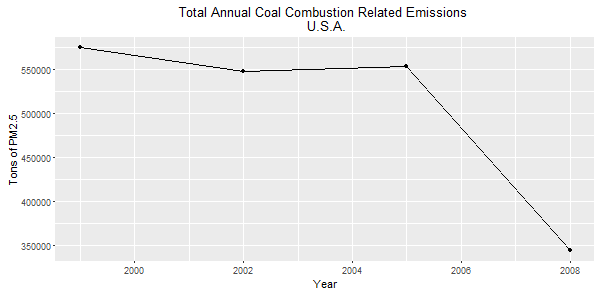

```r
source("plot5.R", echo = TRUE)
```

## Plot6

How have emissions from motor vehicle sources changed from 1999–2008 in Baltimore City?

```
##
## > setwd("~/40 L&G/Coursera/ExDataAnalysis/Project2")
##
## > if (!exists("NEI")) {
## +     NEI <- readRDS(paste0(getwd(), "/Data/summarySCC_PM25.rds"))
## + }
##
## > if (!exists("SCC")) {
## +     SCC <- readRDS(paste0(getwd(), "/Data/Source_Classification_Code.rds"))
## + }
##
## > library(dplyr)
##
## > vehicles <- SCC %>% filter(grepl("Mobile", x = SCC.Level.One,
## +     ignore.case = TRUE)) %>% filter(grepl("vehicle", x = Short.Name,
## +     ignore. .... [TRUNCATED]
##
## > vehicles <- vehicles %>% .$SCC
##
## > png(filename = paste0("plot6.png"), height = 295,
## +     width = 600, bg = "white")
##
## > df <- NEI %>% select(Emissions, year, fips, SCC) %>%
## +     filter(SCC %in% vehicles) %>% filter(fips == "24510") %>%
## +     group_by(year) %>% summ .... [TRUNCATED]
##
## > library(ggplot2)
##
## > qplot(x = year, y = Total, data = df, geom = c("point",
## +     "line"), xlab = "Year", ylab = "Tons of PM2.5", main = "Total Annual Vehicle Related  ..." ... [TRUNCATED]
```

```
##
## > dev.off()
## png
##   2
```

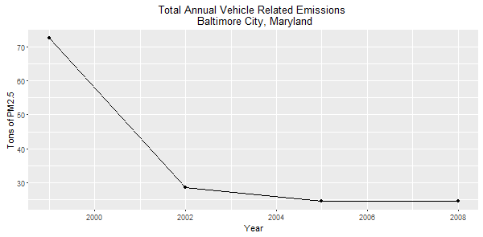

```r
source("plot6.R", echo = TRUE)
```

## Plot 7

Compare emissions from motor vehicle sources in Baltimore City with emissions from motor vehicle sources in Los Angeles County, California (fips == “06037”). Which city has seen greater changes over time in motor vehicle emissions?

```
##
## > setwd("~/40 L&G/Coursera/ExDataAnalysis/Project2")
##
## > if (!exists("NEI")) {
## +     NEI <- readRDS(paste0(getwd(), "/Data/summarySCC_PM25.rds"))
## + }
##
## > if (!exists("SCC")) {
## +     SCC <- readRDS(paste0(getwd(), "/Data/Source_Classification_Code.rds"))
## + }
##
## > library(dplyr)
##
## > vehicles <- SCC %>% filter(grepl("Mobile", x = SCC.Level.One,
## +     ignore.case = TRUE)) %>% filter(grepl("vehicle", x = Short.Name,
## +     ignore. .... [TRUNCATED]
##
## > vehicles <- vehicles %>% .$SCC
##
## > png(filename = paste0("plot7.png"), height = 295,
## +     width = 600, bg = "white")
##
## > df <- NEI %>% select(Emissions, year, fips, SCC) %>%
## +     filter(SCC %in% vehicles) %>% filter(fips == "24510" | fips ==
## +     "06037") %>% mutat .... [TRUNCATED]
##
## > library(ggplot2)
##
## > p <- qplot(x = year, y = Total, data = df, geom = c("point",
## +     "line"), group = City, col = City, xlab = "Year", ylab = "Tons of PM2.5",
## +     .... [TRUNCATED]
##
## > p + geom_smooth(method = "lm")
```

```
##
## > dev.off()
## png
##   2
```

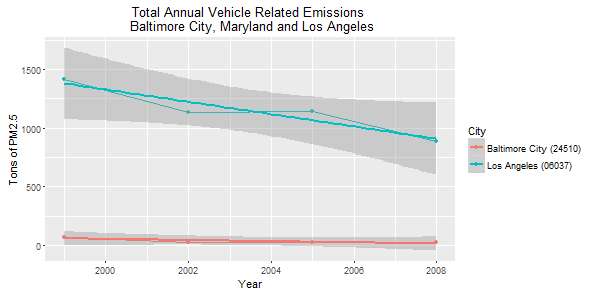

```r
source("plot7.R", echo = TRUE)
```